# VRP BARCELONA 2019 y 2022

- Show All Code
- Hide All Code
- View Source

Author

Dr. Raúl Trujillo

# 1 Lectura de los datos

**Lecturas de datos**

````markdown
```{r}
#| label: tab_summary_year
#| output-location: column
#| tab-cap: "Gráfico de caudales para 2019 y 2022"
#| warning: false

# Understanding box plot:
# https://jingwen-z.github.io/what-is-box-plot/

data_prv %>%
  select(yr, pu, pd, vp, pc, flow) %>%
  tbl_summary(by = yr, missing = "no") %>%
  add_n() %>%
  as_gt() %>%
  gt::tab_source_note(gt::md("*This data is simulated*"))
```
````

| **Characteristic** | **N** | **2019**, N = 35,040<sup>1</sup> | **2022**, N = 33,166<sup>1</sup> |
| --- | --- | --- | --- |
| pu | 68,116 | 3.24 (3.17, 3.41) | 3.49 (3.38, 3.68) |
| pd | 67,862 | 2.89 (2.73, 2.96) | 2.68 (1.96, 3.05) |
| vp | 62,855 | 100 (73, 100) | 75 (62, 100) |
| pc | 32,729 | NA (NA, NA) | 1.21 (1.11, 1.30) |
| flow | 64,696 | 1,409 (1,220, 1,464) | 1,177 (876, 1,318) |

*This data is simulated*  
<sup>1</sup> Median (IQR)

Datos:

- Se leyeron los datos suministrador para los anos 2019 y 2022
- Se cuentan con mediciones cada 15 minutos de:
  - $P_u:$ Presiones en bares aguas arribe de la válvula.
  - $P_d:$ Presiones en bares aguas abajo de la válvula.
  - $P_c:$ Presiones en bares del punto crítico (solo del 2022)
  - $flow:$ flujo a través de la válvula
  - $vp:$ Posición de la válvula en %
- Se removieron las presiones en cero y/o negativas

# 2 Análisis inicial de los datos (visualización exploratoria)

## 2.1 Flujos

### 2.1.1 Flujos en los anos 2019 y 2022

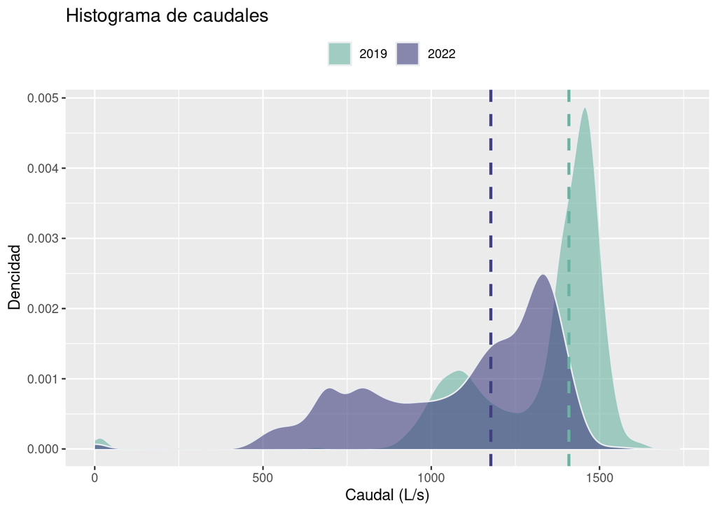

Gráfico de caudales para 2019 y 2022

````markdown
```{r}
#| label: histogram_flow
#| output-location: column
#| fig-cap: "Gráfico de caudales para 2019 y 2022"
#| warning: false

# https://www.tidyverse.org/blog/2020/03/dplyr-1-0-0-summarise/
# https://bookdown.org/content/b298e479-b1ab-49fa-b83d-a57c2b034d49/distributions.html

median_flow <- data_prv %>%
  select(yr, flow) %>%
  group_by(yr) %>%
  summarise(median_flow =median(flow, na.rm=TRUE))

  data_prv %>%
    ggplot(aes(x=flow, fill = yr)) +
    geom_density(color="#e9ecef",
                 alpha=0.6,
                 position = 'identity') +
    scale_fill_manual(values=c("#69b3a2", "#404080")) +
    geom_vline(data=median_flow,
               aes(xintercept=median_flow, color=yr),
               colour = c("#69b3a2", "#404080"),
               size = 1,
               linetype="dashed") +
    theme(legend.position="top") +
    ggtitle("Histograma de caudales") +
    xlab("Caudal (L/s)") +
    ylab("Dencidad") +
    labs(fill="")
```
````

**Note**

*Flujos*

- El flujo medio cada 15 minutos en 2019 fue de 1.409 $l/s$
- El flujo medio cada 15 minutos en 2022 fue de 1.177 $l/s$

## 2.2 Presiones

### 2.2.1 Presiones aguas arriba en los anos 2019 y 2022

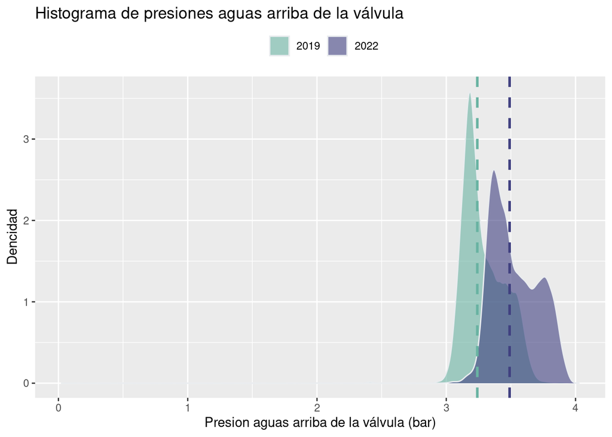

Gráfico de presiones aguas arriba para 2019 y 2022

````markdown
```{r}
#| label: histogram_upstreampressures
#| output-location: column
#| fig-cap: "Gráfico de presiones aguas arriba para 2019 y 2022"
#| warning: false

median_pu <- data_prv %>%
  select(yr, pu) %>%
  group_by(yr) %>%
  summarise(median_pu =median(pu, na.rm=TRUE))

data_prv %>%
  ggplot(aes(x=pu, fill = yr)) +
  geom_density(color="#e9ecef",
               alpha=0.6,
               position = 'identity') +
  scale_fill_manual(values=c("#69b3a2", "#404080")) +
  geom_vline(data=median_pu,
             aes(xintercept=median_pu, color=yr),
             colour = c("#69b3a2", "#404080"),
             size = 1,
             linetype="dashed") +
  theme(legend.position="top") +
  ggtitle("Histograma de presiones aguas arriba de la válvula") +
  xlab("Presion aguas arriba de la válvula (bar)") +
  ylab("Dencidad") +
  labs(fill="")
```
````

**Note**

*Presiones aguas arriba de la válvula*

- La presión media aguas arriba en 2019 fue de 3.24 $bar$
- La presión media aguas arriba en 2022 fue de 3.49 $bar$

### 2.2.2 Presiones aguas abajo en los anos 2019 y 2022

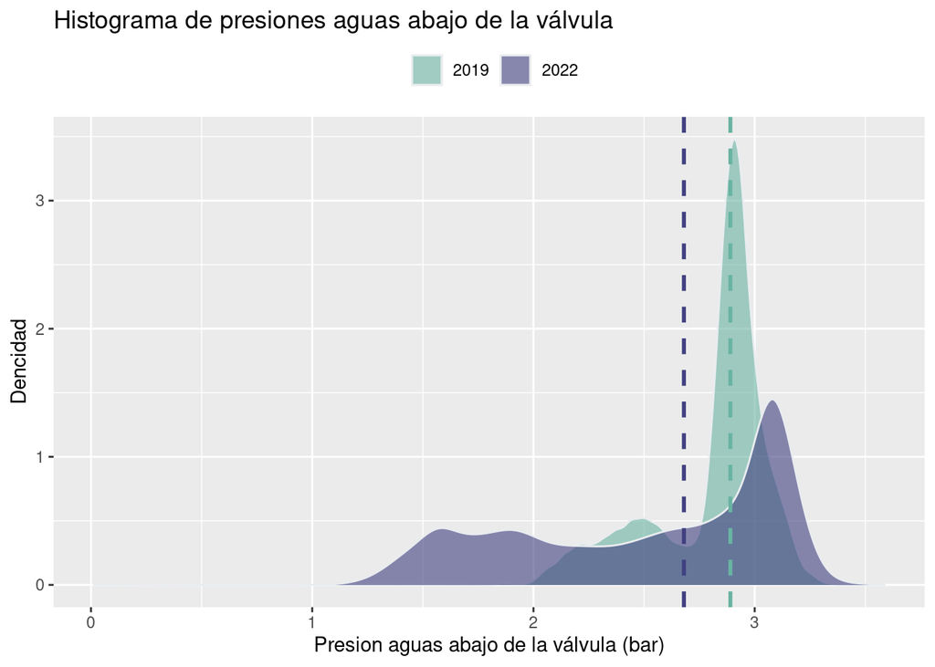

Gráfico de presiones aguas abajo para 2019 y 2022

````markdown
```{r}
#| label: histogram_downstreampressures
#| output-location: column
#| fig-cap: "Gráfico de presiones aguas abajo para 2019 y 2022"
#| warning: false

median_pd <- data_prv %>%
  select(yr, pd) %>%
  group_by(yr) %>%
  summarise(median_pd =median(pd, na.rm=TRUE))

data_prv %>%
  ggplot(aes(x=pd, fill = yr)) +
  geom_density(color="#e9ecef",
               alpha=0.6,
               position = 'identity') +
  scale_fill_manual(values=c("#69b3a2", "#404080")) +
  geom_vline(data=median_pd,
             aes(xintercept=median_pd, color=yr),
             colour = c("#69b3a2", "#404080"),
             size = 1,
             linetype="dashed") +
  theme(legend.position="top") +
  ggtitle("Histograma de presiones aguas abajo de la válvula") +
  xlab("Presion aguas abajo de la válvula (bar)") +
  ylab("Dencidad") +
  labs(fill="")
```
````

**Note**

*Presiones aguas abajo de la válvula*

- La presión media aguas abajo en 2019 fue de 2.89 $bar$
- La presión media aguas abajo en 2022 fue de 2.68 $bar$

### 2.2.3 Presiones punto crítico en 2022

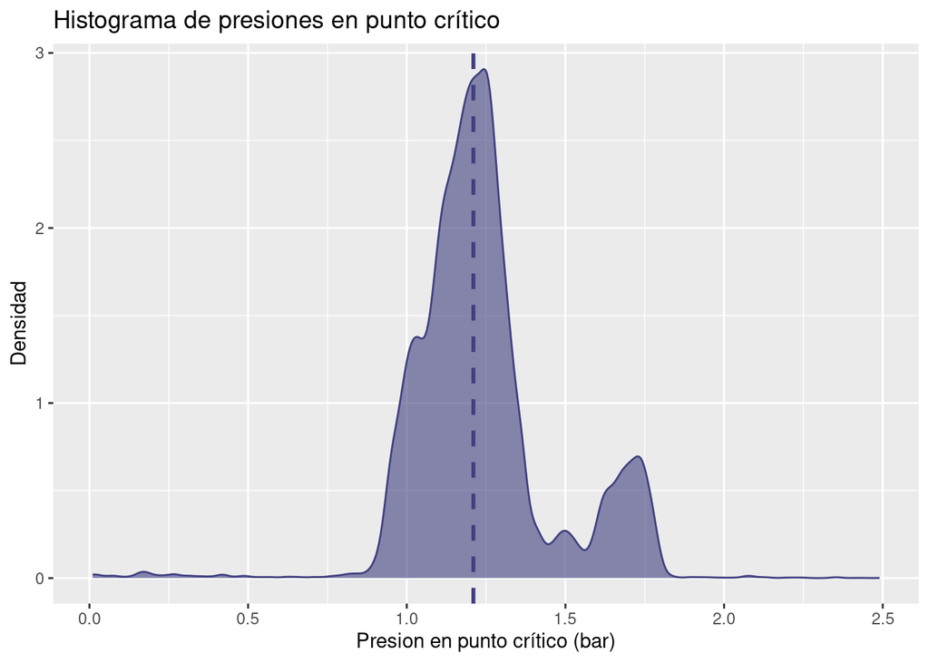

Gráfico de presiones en punto crítico 2022

````markdown
```{r}
#| label: histogram_critical_point_pressures
#| output-location: column
#| fig-cap: "Gráfico de presiones en punto crítico 2022"
#| warning: false

median_pc <- data_prv %>%
  select(yr, pc) %>%
  filter(yr == 2022) %>%
  summarise(median_pc =median(pc, na.rm=TRUE))

data_prv %>%
  ggplot(aes(x=pc)) +
  geom_density(color="#404080",
               fill = "#404080",
               alpha = 0.6,
               position = 'identity') +
    geom_vline(data=median_pc,
               aes(xintercept=median_pc),
               colour = c("#404080"),
               size = 1,
               linetype="dashed") +
    theme(legend.position="top") +
    ggtitle("Histograma de presiones en punto crítico") +
    xlab("Presion en punto crítico (bar)") +
    ylab("Densidad")
```
````

### 2.2.4 Presiones diferenciales entre la presión aguas arriba y la presion en el punto crítico

## 2.3 Posición de operación de la válvula

### 2.3.1 Posición de operación de la válvula anos 2019 y 2022

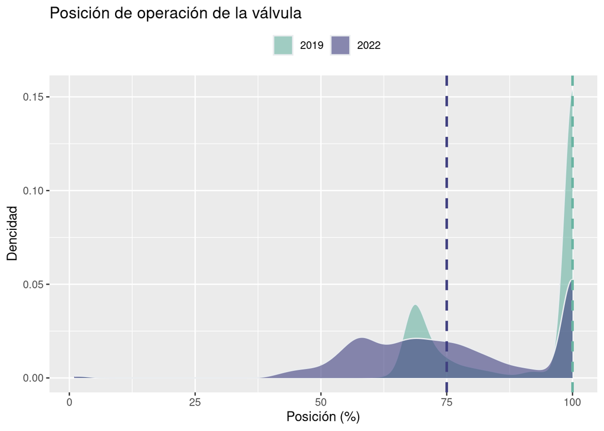

Gráfico de Posición de operación de la válvula para 2019 y 2022

````markdown
```{r}
#| label: histogram_position_valve
#| output-location: column
#| fig-cap: "Gráfico de Posición de operación de la válvula para 2019 y 2022"
#| warning: false

median_vp <- data_prv %>%
  select(yr, vp) %>%
  group_by(yr) %>%
  summarise(median_vp = median(vp, na.rm=TRUE))

data_prv %>%
  ggplot(aes(x=vp, fill = yr)) +
  geom_density(color="#e9ecef",
               alpha=0.6,
               position = 'identity') +
  scale_fill_manual(values=c("#69b3a2", "#404080")) +
  geom_vline(data=median_vp,
             aes(xintercept=median_vp, color=yr),
             colour = c("#69b3a2", "#404080"),
             size = 1,
             linetype="dashed") +
  theme(legend.position="top") +
  ggtitle("Posición de operación de la válvula") +
  xlab("Posición (%)") +
  ylab("Dencidad") +
  labs(fill="")
```
````

**Note**

*Posición de operación de la válvula*

- La posición media de la válvula en 2019 fue del 100%
- La posición media de la válvula en 2022 fue del 75%

## 2.4 Coeficiente de flujo $Kv$ de la válvula